# Codebook example with Qualtrics dataset

Ruben Arslan

2026-03-02

```r
knit_by_pkgdown <- !is.null(knitr::opts_chunk$get("fig.retina"))
knitr::opts_chunk$set(warning = FALSE, message = FALSE, error = FALSE, echo = TRUE)
ggplot2::theme_set(ggplot2::theme_bw())
library(codebook)
library(dplyr)
```

Here, I try to demonstrate that we can also use the metadata generated by Qualtrics. Because I am not a Qualtrics user, the developer of the `qualtRics` R package sent me two example files, one of data and one for metadata, which I use here. Usually, you’d import these files directly via his package.

## Load

```r
# library(qualtRics) # currently not on CRAN, so commented out
results <- readRDS(system.file("extdata", "ryan.rds", package = "codebook"))
metadata_ex <- readRDS(system.file("extdata", "metadata.rds", package = "codebook"))
```

Now, we want the metadata not to be just independent of the data frame. It’s easier to change metadata if it is in the form of a list at the dataset level, so let’s use `rio::gather_attrs` for that.

```r
results <- results %>% rio::gather_attrs()
attributes(results)$label$Q7
```

```
##                                                                                  Q7
## "How reasonable or unreasonable is the cost of courses/tuition at this university?"
```

Now, we can loop over the metadata list and put it in the right shape to become attributes. This means given each element the name of the variable it refers to.

```r
names(metadata_ex$questions) <- lapply(metadata_ex$questions, function(x) {
  x$questionName
})
```

We only want the questions that we have data for.

```r
qs <- names(metadata_ex$questions)
qs <- qs[qs %in% names(attributes(results)$label)]
```

Now, we assign our metadata list to the attributes of the data.frame.

```r
init <- vector("list", ncol(results))
names(init) <- names(results)
attributes(results)$item <- init
attributes(results)$item[qs] <- metadata_ex$questions[qs]
```

And use rio to put the attributes on the question level again.

```r
results <- results %>% rio::spread_attrs()
```

To keep this example, we select a subset of variables.

```r
results <- results %>% select(ResponseSet, Q7, Q10)
if (!knit_by_pkgdown) knitr::opts_chunk$set(echo = FALSE)
```

Please note, that we just reuse the metadata column names from Qualtrics. Standardising this across multiple survey providers would be great but requires more knowledge of Qualtrics than I have.

[output not shown]

### Metadata

#### Description

**Dataset name**: MOCK Qualtrics dataset

a MOCK dataset used to show how to import Qualtrics metadata into the codebook R package

**Metadata for search engines**

- **Temporal Coverage**: 2018
- **Spatial Coverage**: Nowhere
- **URL**: https://rubenarslan.github.io/codebook/articles/codebook_qualtrics.html
- **Identifier**: [doi:10.5281/zenodo.1326520](https://dx.doi.org/10.5281/zenodo.1326520)
- **Date published**: 2018-08-01
- **Creator**:

| name | value |
| --- | --- |
| @type | Person |
| givenName | Ruben |
| familyName | Arslan |
| email | ruben.arslan@gmail.com |
| affiliation | @type: Organization, name: MPI Human Development, Berlin |

| name | value |
| --- | --- |
| keywords | ResponseSet, Q7, Q10 |

## Variables

### ResponseSet

ResponseSet

#### Distribution

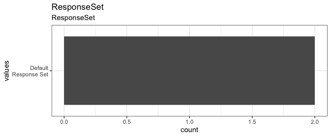

Distribution of values for ResponseSet

0 missing values.

#### Summary statistics

| name | data_type | n_missing | complete_rate | n_unique | empty | min | max | whitespace | ResponseSet | label |
| --- | --- | --- | --- | --- | --- | --- | --- | --- | --- | --- |
| ResponseSet | character | 0 | 1 | 1 | 0 | 20 | 20 | 0 | ResponseSet | NA |

### Q7

How reasonable or unreasonable is the cost of courses/tuition at this university?

#### Distribution

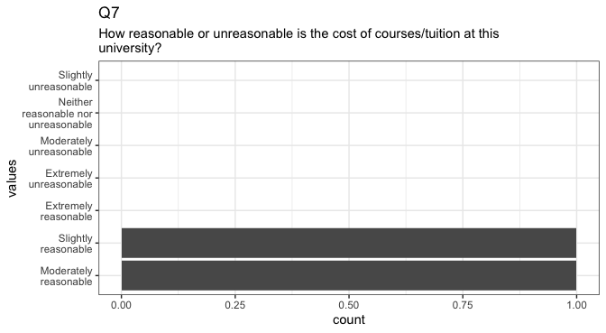

Distribution of values for Q7

0 missing values.

#### Summary statistics

| name | type | data_type | ordered | value_labels | n_missing | complete_rate | n_unique | top_counts | Q7 | selector | subSelector | questionText | doesForceResponse | questionName | label |
| --- | --- | --- | --- | --- | --- | --- | --- | --- | --- | --- | --- | --- | --- | --- | --- |
| Q7 | MC | factor | TRUE | 1. Extremely reasonable, 2. Moderately reasonable, 3. Slightly reasonable, 4. Neither reasonable nor unreasonable, 5. Slightly unreasonable, 6. Moderately unreasonable, 7. Extremely unreasonable | 0 | 1 | 2 | Mod: 1, Sli: 1, Ext: 0, Nei: 0 | How reasonable or unreasonable is the cost of courses/tuition at this university? | SAVR | TX | How reasonable or unreasonable is the cost of courses/tuition at this university? | FALSE | Q7 | NA |

#### Item

Item options

| type | selector | subSelector | questionText | doesForceResponse | questionName |
| --- | --- | --- | --- | --- | --- |
| MC | SAVR | TX | How reasonable or unreasonable is the cost of courses/tuition at this university? | FALSE | Q7 |

#### Value labels

Response choices

| name | value |
| --- | --- |
| 1 | 1 , Extremely reasonable, Extremely reasonable, TRUE |
| 2 | 2 , Moderately reasonable, Moderately reasonable, TRUE |
| 3 | 3 , Slightly reasonable, Slightly reasonable, TRUE |
| 4 | 4 , Neither reasonable nor unreasonable, Neither reasonable nor unreasonable, TRUE |
| 5 | 5 , Slightly unreasonable, Slightly unreasonable, TRUE |
| 6 | 6 , Moderately unreasonable, Moderately unreasonable, TRUE |
| 7 | 7 , Extremely unreasonable, Extremely unreasonable, TRUE |

### Q10

How helpful or unhelpful is the staff at the on-campus health center?

#### Distribution

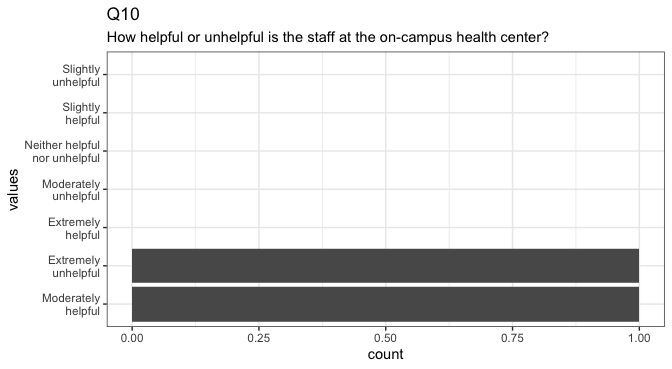

Distribution of values for Q10

0 missing values.

#### Summary statistics

| name | type | data_type | ordered | value_labels | n_missing | complete_rate | n_unique | top_counts | Q10 | selector | subSelector | questionText | doesForceResponse | questionName | label |
| --- | --- | --- | --- | --- | --- | --- | --- | --- | --- | --- | --- | --- | --- | --- | --- |
| Q10 | MC | factor | TRUE | 1. Extremely helpful, 2. Moderately helpful, 3. Slightly helpful, 4. Neither helpful nor unhelpful, 5. Slightly unhelpful, 6. Moderately unhelpful, 7. Extremely unhelpful | 0 | 1 | 2 | Mod: 1, Ext: 1, Ext: 0, Sli: 0 | How helpful or unhelpful is the staff at the on-campus health center? | SAVR | TX | How helpful or unhelpful is the staff at the on-campus health center? | FALSE | Q10 | NA |

#### Item

Item options

| type | selector | subSelector | questionText | doesForceResponse | questionName |
| --- | --- | --- | --- | --- | --- |
| MC | SAVR | TX | How helpful or unhelpful is the staff at the on-campus health center? | FALSE | Q10 |

#### Value labels

Response choices

| name | value |
| --- | --- |
| 1 | 1 , Extremely helpful, Extremely helpful, TRUE |
| 2 | 2 , Moderately helpful, Moderately helpful, TRUE |
| 3 | 3 , Slightly helpful, Slightly helpful, TRUE |
| 4 | 4 , Neither helpful nor unhelpful, Neither helpful nor unhelpful, TRUE |
| 5 | 5 , Slightly unhelpful, Slightly unhelpful, TRUE |
| 6 | 6 , Moderately unhelpful, Moderately unhelpful, TRUE |
| 7 | 7 , Extremely unhelpful, Extremely unhelpful, TRUE |

## Missingness report

### Codebook table

| name | type | data_type | ordered | value_labels | n_missing | complete_rate | n_unique | empty | top_counts | min | max | whitespace | ResponseSet | Q7 | selector | subSelector | questionText | doesForceResponse | questionName | Q10 | label |
| --- | --- | --- | --- | --- | --- | --- | --- | --- | --- | --- | --- | --- | --- | --- | --- | --- | --- | --- | --- | --- | --- |
| ResponseSet | NA | character | NA | NA | 0 | 1 | 1 | 0 | NA | 20 | 20 | 0 | ResponseSet | NA | NA | NA | NA | NA | NA | NA | NA |
| Q7 | MC | factor | TRUE | 1. Extremely reasonable, 2. Moderately reasonable, 3. Slightly reasonable, 4. Neither reasonable nor unreasonable, 5. Slightly unreasonable, 6. Moderately unreasonable, 7. Extremely unreasonable | 0 | 1 | 2 | NA | Mod: 1, Sli: 1, Ext: 0, Nei: 0 | NA | NA | NA | NA | How reasonable or unreasonable is the cost of courses/tuition at this university? | SAVR | TX | How reasonable or unreasonable is the cost of courses/tuition at this university? | FALSE | Q7 | NA | NA |
| Q10 | MC | factor | TRUE | 1. Extremely helpful, 2. Moderately helpful, 3. Slightly helpful, 4. Neither helpful nor unhelpful, 5. Slightly unhelpful, 6. Moderately unhelpful, 7. Extremely unhelpful | 0 | 1 | 2 | NA | Mod: 1, Ext: 1, Ext: 0, Sli: 0 | NA | NA | NA | NA | NA | SAVR | TX | How helpful or unhelpful is the staff at the on-campus health center? | FALSE | Q10 | How helpful or unhelpful is the staff at the on-campus health center? | NA |